# Figures of the maternal T1D methylation analysis

## 0.43 Extended Data Figure 2g

Correlation plot showing blood methylation values of maternal T1D associated CpGs between the Illumina EPIC array and bisulfite pyrosequencing in young children.

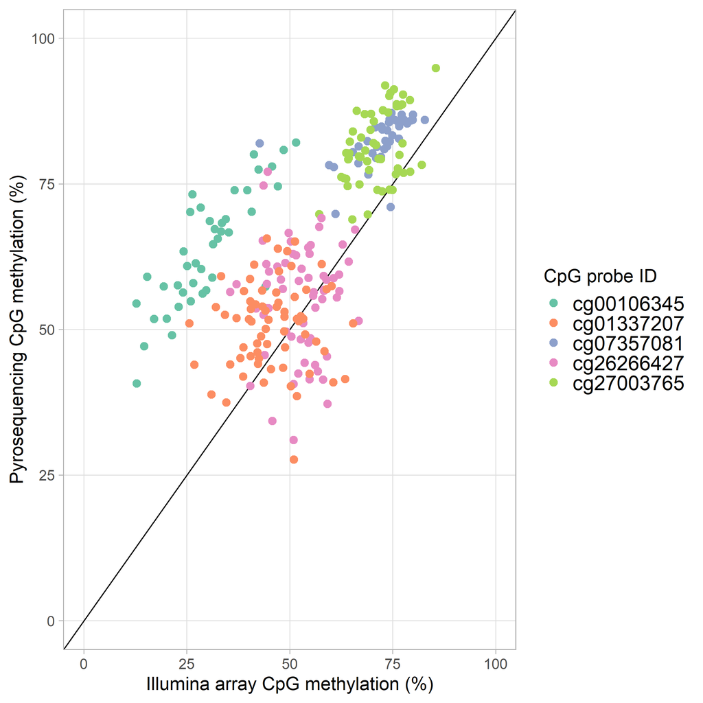

```r
# Extended Data Figure 2g

ExtDataFig2g <- ggplot(ExtDataFig2g_data,
                       aes(x = Array,
                           y = Pyrosequencing,
                           color = CpG)) +
  geom_point(shape = 21) +
  scale_colour_brewer(palette = "Set2") +
  geom_abline(intercept = 0) +
  scale_y_continuous(limits = c(0, 100),
                     breaks = c(0, 25, 50, 75, 100)) +
  scale_x_continuous(limits = c(0, 100),
                     breaks = c(0, 25, 50, 75, 100)) +
  theme_light(base_size = 16) +
  theme(panel.grid.minor = element_blank(),
        legend.text = element_text(size = rel(1.1))) +
  labs(x = "Illumina array CpG methylation (%)",
       y = "Pyrosequencing CpG methylation (%)",
       color = "CpG probe ID")

jit <- position_jitter(seed = 123)

ExtDataFig2g + geom_jitter(aes(color = CpG),
                           size = 3,
                           position = jit)
```

## 0.44 Extended Data Figure 2h

Methylation levels at CpGs linked to T1D susceptibility genes (SKAP2, SLC4A44, LY6G5B, TNXB, SKIV2L) in children with mothers with T1D vs. children with unaffected mothers determined by Illumina EPIC array or bisulfite pyrosequencing. A schematic regulatory map is shown above each CpG based on the eQTM-derived CpG target genes.

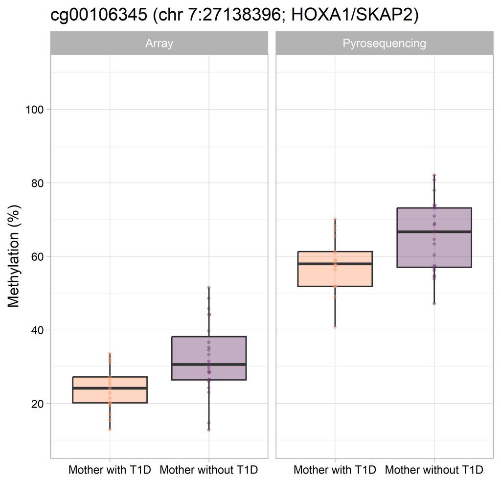

```r
# Extended Data Figure 2h

color<-c("#663366", "#FF9966")
alpha_color <- 1
alpha_fill <- 0.9

ExtDataFig2h <- ggplot(ExtDataFig2h_data,
                       aes(x = factor(group),
                           y = cg00106345)) +
  geom_boxplot(aes(fill = factor(group)),
               alpha = 0.4,
               cex = 0.8,
               show.legend = FALSE) +
  geom_beeswarm(aes(color = factor(group)),
                alpha = 0.4,
                cex = 0.4,
                show.legend = FALSE,
                size = 1.5) +
  scale_color_manual(breaks = c("Mother without T1D", "Mother with T1D"),
                     values = alpha(color, alpha_color)) +
  scale_fill_manual(breaks = c("Mother without T1D", "Mother with T1D"),
                    values = alpha(color, alpha_fill)) +
  theme_light(base_size = 18) +
  theme(axis.text = element_text(size = 14,
                                 colour = "black")) +
  scale_y_continuous(limits = c(10,110),
                     breaks = c(20,40,60,80,100)) +
  labs(title = "cg00106345 (chr 7:27138396; HOXA1/SKAP2)",
       x = "",
       y = "Methylation (%)") +
  facet_wrap(~analysis,
             ncol = 2)

print(ExtDataFig2h)
```

## 0.45 Extended Data Figure 2i

Methylation levels at CpGs linked to T1D susceptibility genes (SKAP2, SLC4A44, LY6G5B, TNXB, SKIV2L) in children with mothers with T1D vs. children with unaffected mothers determined by Illumina EPIC array or bisulfite pyrosequencing. A schematic regulatory map is shown above each CpG based on the eQTM-derived CpG target genes.

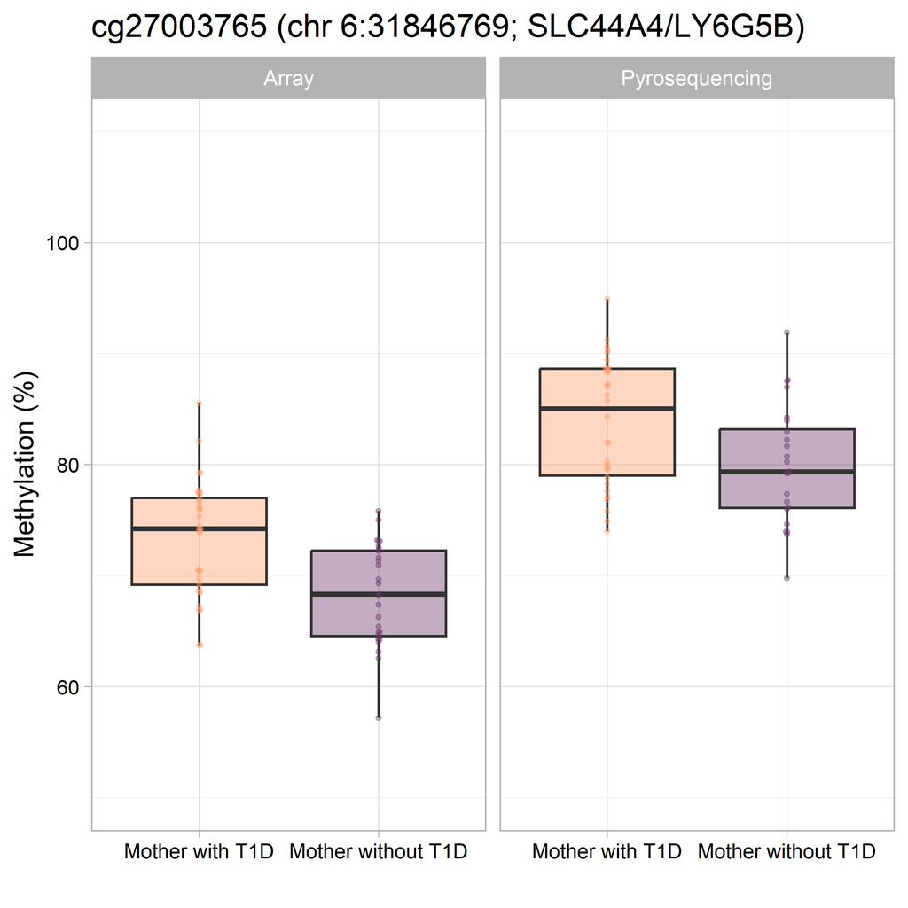

```r
# Extended Data Figure 2i

color<-c("#663366", "#FF9966")
alpha_color <- 1
alpha_fill <- 0.9

ExtDataFig2i <- ggplot(ExtDataFig2i_data,
                       aes(x = factor(group),
                           y = cg27003765)) +
  geom_boxplot(aes(fill = factor(group)),
               alpha = 0.4,
               cex = 0.8,
               show.legend = FALSE) +
  geom_beeswarm(aes(color = factor(group)),
                alpha = 0.4,
                cex = 0.4,
                show.legend = FALSE,
                size = 1.5) +
  scale_color_manual(breaks = c("Mother without T1D", "Mother with T1D"),
                     values = alpha(color, alpha_color)) +
  scale_fill_manual(breaks = c("Mother without T1D", "Mother with T1D"),
                    values = alpha(color, alpha_fill)) +
  theme_light(base_size = 18) +
  theme(axis.text = element_text(size = 14,
                                 colour = "black")) +
  scale_y_continuous(limits = c(50,110),
                     breaks = c(20,40,60,80,100)) +
  labs(title = "cg27003765 (chr 6:31846769; SLC44A4/LY6G5B)",
       x = "",
       y = "Methylation (%)") +
  facet_wrap(~analysis,
             ncol = 2)

print(ExtDataFig2i)
```

## 0.46 Extended Data Figure 2j

Methylation levels at CpGs linked to T1D susceptibility genes (SKAP2, SLC4A44, LY6G5B, TNXB, SKIV2L) in children with mothers with T1D vs. children with unaffected mothers determined by Illumina EPIC array or bisulfite pyrosequencing. A schematic regulatory map is shown above each CpG based on the eQTM-derived CpG target genes.

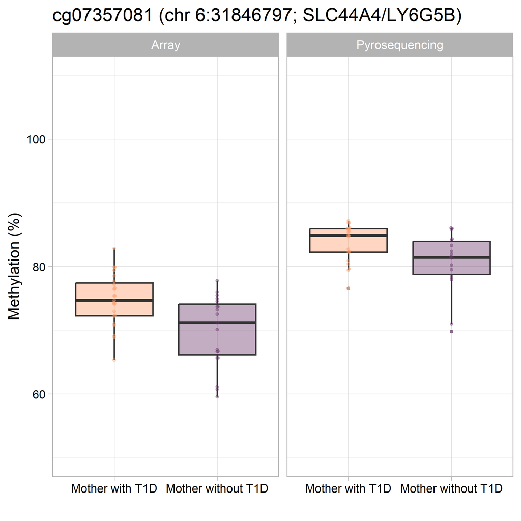

```r
# Extended Data Figure 2j

color<-c("#663366", "#FF9966")
alpha_color <- 1
alpha_fill <- 0.9

ExtDataFig2j <- ggplot(ExtDataFig2j_data,
                       aes(x = factor(group),
                           y = cg07357081)) +
  geom_boxplot(aes(fill = factor(group)),
               alpha = 0.4,
               cex = 0.8,
               show.legend = FALSE) +
  geom_beeswarm(aes(color = factor(group)),
                alpha = 0.4,
                cex = 0.4,
                show.legend = FALSE,
                size = 1.5) +
  scale_color_manual(breaks = c("Mother without T1D", "Mother with T1D"),
                     values = alpha(color, alpha_color)) +
  scale_fill_manual(breaks = c("Mother without T1D", "Mother with T1D"),
                    values = alpha(color, alpha_fill)) +
  theme_light(base_size = 18) +
  theme(axis.text = element_text(size = 14,
                                 colour = "black"))+
  scale_y_continuous(limits = c(50,110),
                     breaks = c(20,40,60,80,100)) +
  labs(title = "cg07357081 (chr 6:31846797; SLC44A4/LY6G5B)",
       x = "",
       y = "Methylation (%)") +
  facet_wrap(~analysis,
             ncol = 2)

print(ExtDataFig2j)
```

## 0.47 Extended Data Figure 2k

Methylation levels at CpGs linked to T1D susceptibility genes (SKAP2, SLC4A44, LY6G5B, TNXB, SKIV2L) in children with mothers with T1D vs. children with unaffected mothers determined by Illumina EPIC array or bisulfite pyrosequencing. A schematic regulatory map is shown above each CpG based on the eQTM-derived CpG target genes.

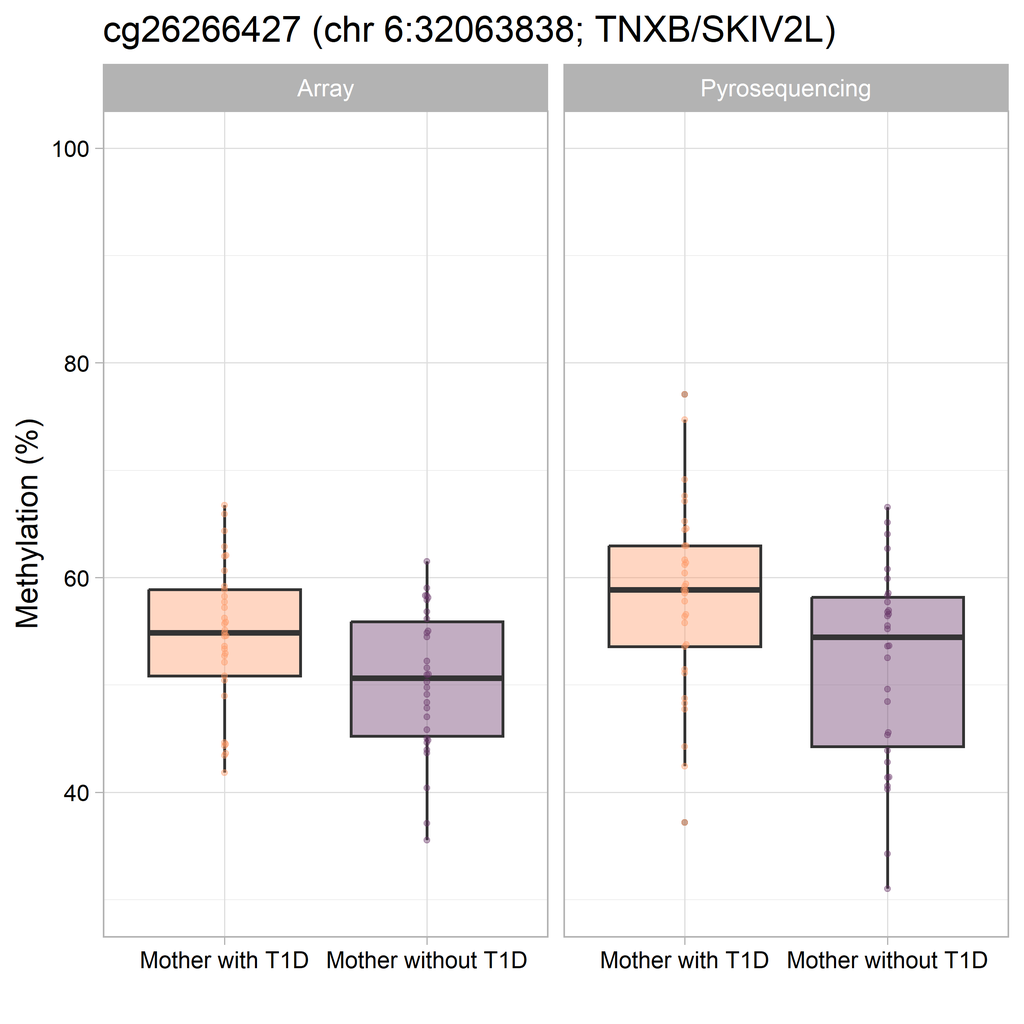

```r
# Extended Data Figure 2k

color<-c("#663366", "#FF9966")
alpha_color <- 1
alpha_fill <- 0.9

ExtDataFig2k <- ggplot(ExtDataFig2k_data,
                       aes(x = factor(group),
                           y = cg26266427)) +
  geom_boxplot(aes(fill = factor(group)),
               alpha = 0.4,
               cex = 0.8,
               show.legend = FALSE) +
  geom_beeswarm(aes(color = factor(group)),
                alpha = 0.4,
                cex = 0.4,
                show.legend = FALSE,
                size = 1.5) +
  scale_color_manual(breaks = c("Mother without T1D", "Mother with T1D"),
                     values = alpha(color, alpha_color)) +
  scale_fill_manual(breaks = c("Mother without T1D", "Mother with T1D"),
                    values = alpha(color, alpha_fill)) +
  theme_light(base_size = 18) +
  theme(axis.text = element_text(size = 14,
                                 colour = "black"))+
  scale_y_continuous(limits = c(30,100),
                     breaks = c(40,60,80,100)) +
  labs(title="cg26266427 (chr 6:32063838; TNXB/SKIV2L)",
       x = "",
       y = "Methylation (%)") +
  facet_wrap(~analysis,
             ncol = 2)

print(ExtDataFig2k)
```

## 0.48 Extended Data Figure 2l

Methylation levels at CpGs linked to T1D susceptibility genes (SKAP2, SLC4A44, LY6G5B, TNXB, SKIV2L) in children with mothers with T1D vs. children with unaffected mothers determined by Illumina EPIC array or bisulfite pyrosequencing. A schematic regulatory map is shown above each CpG based on the eQTM-derived CpG target genes.

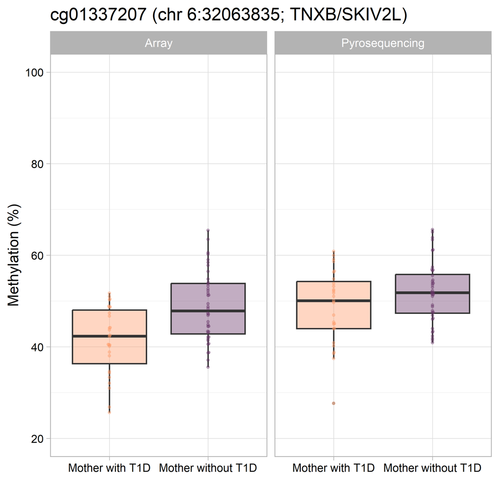

```r
# Extended Data Figure 2l

color<-c("#663366", "#FF9966")
alpha_color <- 1
alpha_fill <- 0.9

ExtDataFig2l <- ggplot(ExtDataFig2l_data,
                       aes(x = factor(group),
                           y = cg01337207)) +
  geom_boxplot(aes(fill = factor(group)),
               alpha = 0.4,
               cex = 0.8,
               show.legend = FALSE) +
  geom_beeswarm(aes(color = factor(group)),
                alpha = 0.4,
                cex = 0.4,
                show.legend = FALSE,
                size = 1.5) +
  scale_color_manual(breaks = c("Mother without T1D", "Mother with T1D"),
                     values = alpha(color, alpha_color)) +
  scale_fill_manual(breaks = c("Mother without T1D", "Mother with T1D"),
                    values = alpha(color, alpha_fill)) +
  theme_light(base_size = 18) +
  theme(axis.text = element_text(size = 14,
                                 colour = "black")) +
  scale_y_continuous(limits = c(20,100),
                     breaks = c(20,40,60,80,100)) +
  labs(title = "cg01337207 (chr 6:32063835; TNXB/SKIV2L)",
       x = "",
       y = "Methylation (%)") +
  facet_wrap(~analysis,
             ncol = 2)

print(ExtDataFig2l)
```

## 0.49 Extended Data Figure 3

Heatmaps of all and top 20 maternal T1D associated CpG sites. a, Heatmap of adjusted and scaled methylation M-values of 1,752 children across the 1,677 CpG sites associated with maternal T1D. b, Heatmap of adjusted and scaled methylation M-values of the 20 most significant CpGs of 1,752 children. Illumina probe IDs and annotated genes are shown aside each row. CpG clustering was performed based on Euclidean distance.

## 0.50 Extended Data Figure 3a

Heatmap of adjusted and scaled methylation M-values of 1,752 children across the 1,677 CpG sites associated with maternal T1D.

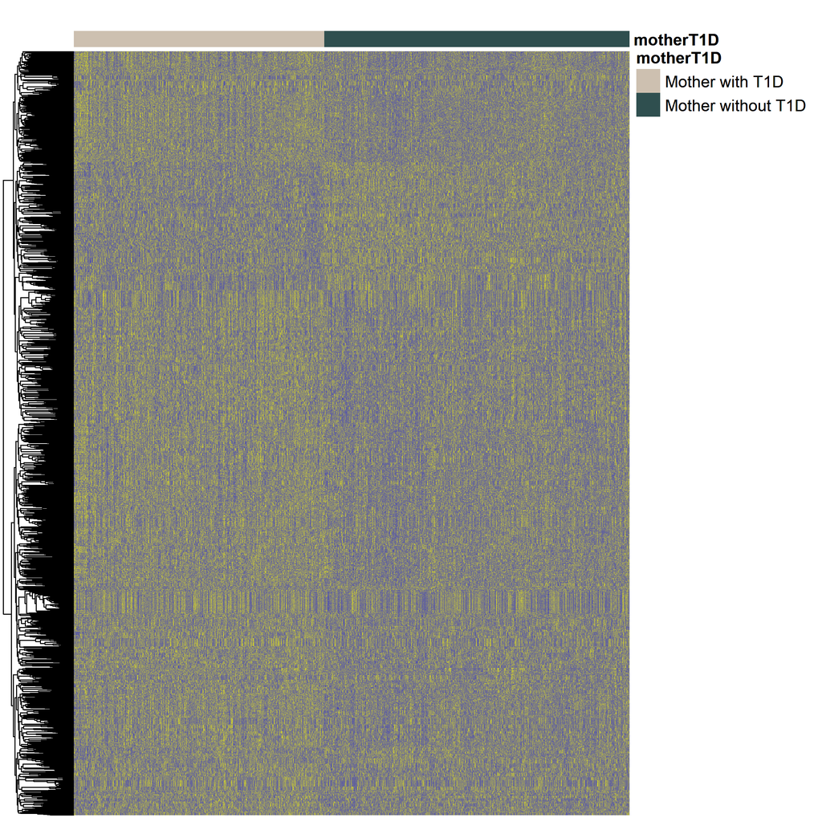

```r
# Extended Data Figure 3a

set.seed(1984)

# reorder the matrix based in the annotation
ExtDataFig3a_data <- ExtDataFig3a_data[,rownames(ExtDataFig3a_groups)]

# set colors
ann_colors = list(
  motherT1D = c(`Mother with T1D`="antiquewhite3",
                `Mother without T1D`="darkslategrey"))

paletteLength <- 6
heat_color <- colorRampPalette(c('blue', 'yellow'))(paletteLength)

# set color breaks
heat_breaks <- c(seq(min(ExtDataFig3a_data),
                     0,
                     length.out = ceiling(paletteLength/2) + 1),
              seq(max(ExtDataFig3a_data)/paletteLength,
                  max(ExtDataFig3a_data),
                  length.out = floor(paletteLength/2)))

# plot heatmap
ExtDataFig3a <- pheatmap(mat = ExtDataFig3a_data,
                         color = heat_color,
                         breaks = heat_breaks,
                         border_color = NA,
                         show_colnames = FALSE,
                         show_rownames = FALSE,
                         cluster_cols = FALSE,
                         cluster_rows = TRUE,
                         annotation_col = ExtDataFig3a_groups,
                         annotation_colors = ann_colors,
                         drop_levels = TRUE,
                         fontsize = 12,
                         legend = FALSE,
                         main = "")

print(ExtDataFig3a)
```

## 0.51 Extended Data Figure 3b

Heatmap of adjusted and scaled methylation M-values of the 20 most significant CpGs of 1,752 children. Illumina probe IDs and annotated genes are shown aside each row.

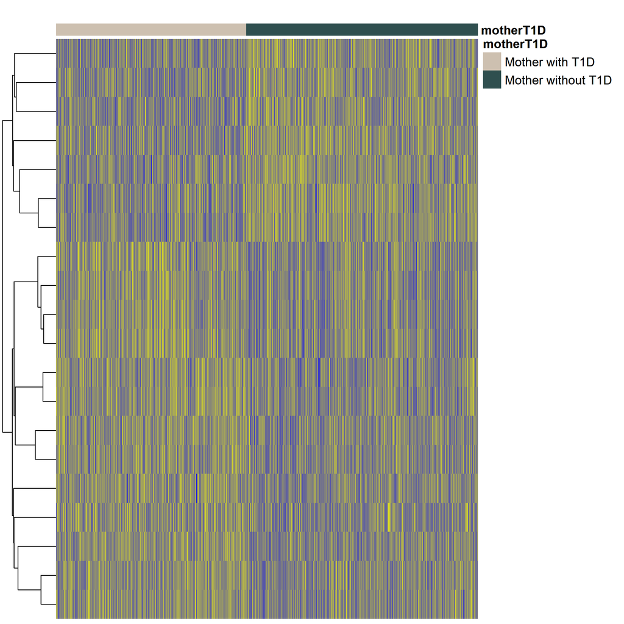

```r
# Extended Data Figure 3b

set.seed(1984)

# reorder the matrix based in the annotation
ExtDataFig3b_data <- ExtDataFig3b_data[,rownames(ExtDataFig3_groups)]

#set colors
ann_colors = list(
  motherT1D = c(`Mother with T1D`="antiquewhite3",
                `Mother without T1D`="darkslategrey"))

paletteLength <- 6
heat_color <- colorRampPalette(c('blue', 'yellow'))(paletteLength)

# set color breaks
heat_breaks <- c(seq(min(ExtDataFig3b_data),
                     0,
                     length.out = ceiling(paletteLength/2) + 1),
              seq(max(ExtDataFig3b_data)/paletteLength,
                  max(ExtDataFig3b_data),
                  length.out = floor(paletteLength/2)))

# plot heatmap
ExtDataFig3b <- pheatmap(mat = ExtDataFig3b_data,
                         color = heat_color,
                         breaks = heat_breaks,
                         border_color = NA,
                         show_colnames = FALSE,
                         show_rownames = FALSE,
                         cluster_cols = FALSE,
                         cluster_rows = TRUE,
                         annotation_col = ExtDataFig3_groups,
                         annotation_colors = ann_colors,
                         drop_levels = TRUE,
                         fontsize = 12,
                         legend = FALSE,
                         main = "")

print(ExtDataFig3b)
```

## 0.52 Extended Data Figure 4

Methylation propensity score (MPS) of 28 CpGs linked to T1D susceptibility genes. a, The MPS based on 28 CpGs linked to T1D susceptibility genes by maternal T1D status (ntotal = 1,752, n children with a mother with T1D = 789). b, The MPS based on 28 CpGs linked to T1D susceptibility genes in children not exposed to maternal T1D by islet autoimmunity outcome (ntotal = 963, n children who developed islet autoimmunity = 81). c, The MPS based on 28 CpGs linked to T1D susceptibility genes in children with a father and/or sibling with T1D by islet autoimmunity outcome (ntotal = 604, n children who developed islet autoimmunity = 58). d, The MPS based on 28 CpGs linked to T1D susceptibility genes in children without a first-degree relative with T1D by islet autoimmunity outcome (ntotal = 359, n children who developed islet autoimmunity = 23). e, Validation of the MPS based on 28 CpGs linked to T1D susceptibility in children without a mother with T1D from an independent cohort (Fr1da) by islet autoimmunity outcome (ntotal = 303, n children who developed islet autoimmunity = 161). Box-plots indicate the median and the 25th and 75th percentile. P-values derived from adjusted logistic regression.

## 0.53 Extended Data Figure 4a

The MPS based on 28 CpGs linked to T1D susceptibility genes by maternal T1D status (ntotal = 1,752, n children with a mother with T1D = 789).

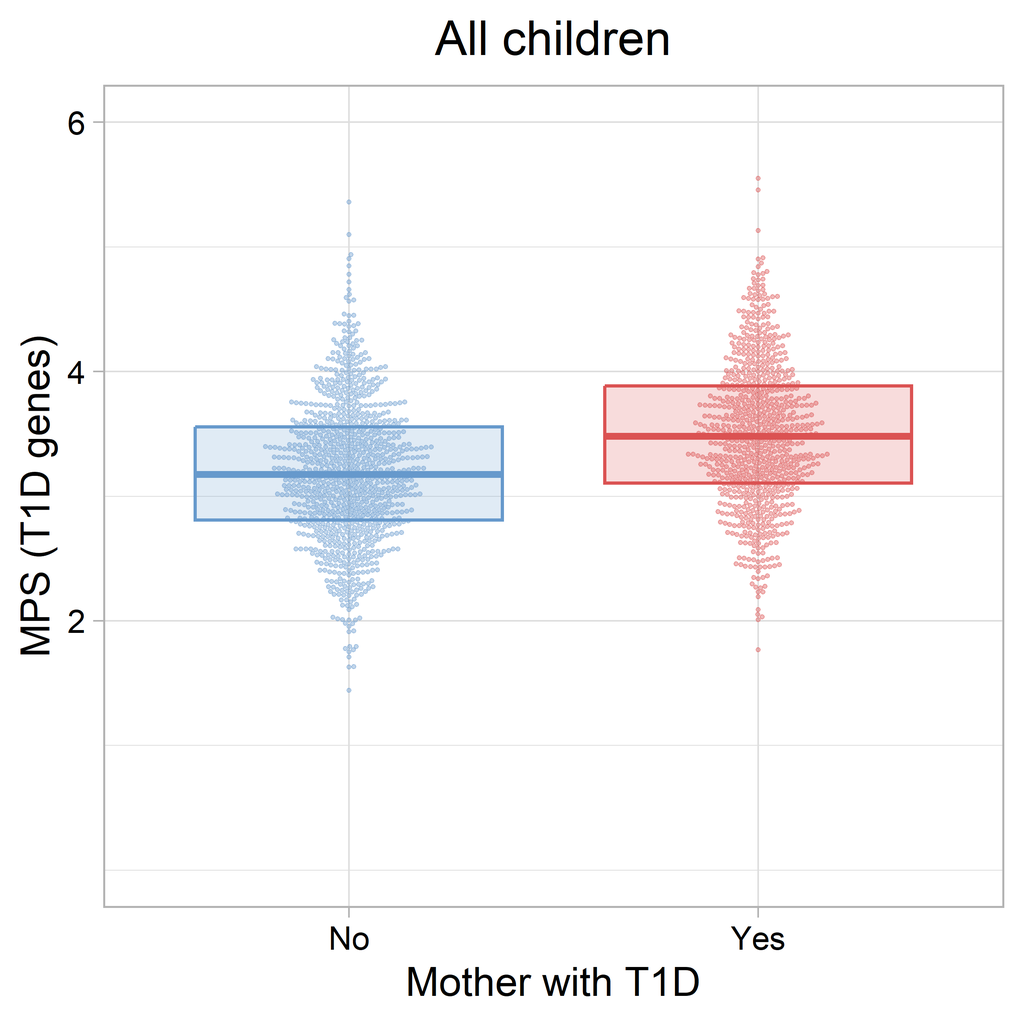

```r
# Extended Data Figure 4a

color<-c("#6699CC", "#DB5252")
alpha_color <- 1
alpha_fill <- 0.2

ExtDataFig4a <- ggplot(ExtDataFig4a_data,
                aes(x = motherT1D,
                    y = MPS)) +
  geom_boxplot(aes(color = motherT1D,
                   fill = motherT1D),
               outlier.shape = NA,
               coef=0,
               show.legend = FALSE,
               linewidth = 1) +
  geom_beeswarm(aes(color = motherT1D),
                alpha = 0.4,
                cex = 0.6,
                show.legend = FALSE,
                size = 1) +
  scale_color_manual(breaks = c("No", "Yes"),
                     values = ggplot2::alpha(color,
                                             alpha_color)) +
  scale_fill_manual(breaks = c("No", "Yes"),
                    values = ggplot2::alpha(color,
                                            alpha_fill)) +
  scale_y_continuous(limits=c(0, 6), breaks = c(2, 4, 6)) +
  theme_light(base_size = 24) +
  theme(axis.text = element_text(colour = "black"),
        plot.title = element_text(hjust = 0.5)) +
  ylab("MPS (T1D genes)") +
  xlab("Mother with T1D") +
  ggtitle("All children")

print(ExtDataFig4a)
```

## 0.54 Extended Data Figure 4b

The MPS based on 28 CpGs linked to T1D susceptibility genes in children not exposed to maternal T1D by islet autoimmunity outcome (ntotal = 963, n children who developed islet autoimmunity = 81).

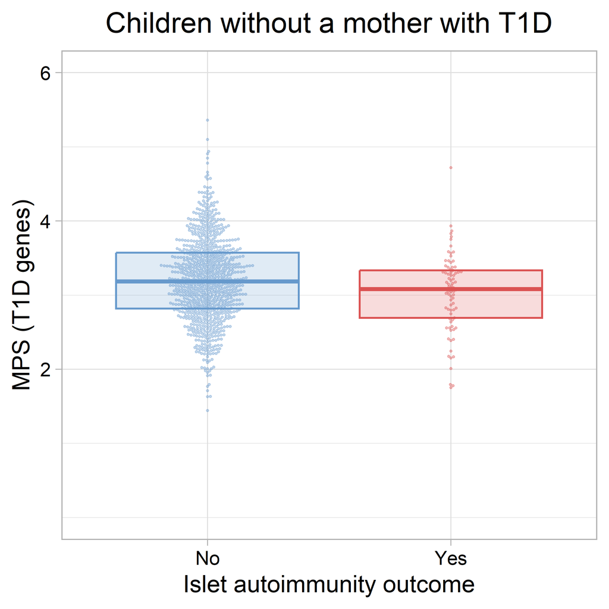

```r
# Extended Data Figure 4b

color<-c("#6699CC", "#DB5252")
alpha_color <- 1
alpha_fill <- 0.2

ExtDataFig4b <- ggplot(ExtDataFig4b_data,
                aes(x = IA_outcome,
                    y = MPS)) +
  geom_boxplot(aes(color = IA_outcome,
                   fill = IA_outcome),
               outlier.shape = NA,
               coef = 0,
               show.legend = FALSE,
               linewidth = 1) +
  geom_beeswarm(aes(color = IA_outcome),
                alpha = 0.4,
                cex = 0.6,
                show.legend = FALSE,
                size = 1) +
  scale_color_manual(breaks = c("No", "Yes"),
                     values = ggplot2::alpha(color,
                                             alpha_color)) +
  scale_fill_manual(breaks = c("No", "Yes"),
                    values = ggplot2::alpha(color,
                                            alpha_fill)) +
  scale_y_continuous(limits=c(0, 6), breaks = c(2, 4, 6)) +
  theme_light(base_size = 24) +
  theme(axis.text = element_text(colour = "black"),
        plot.title = element_text(hjust = 0.5)) +
  ylab("MPS (T1D genes)") +
  xlab("Islet autoimmunity outcome") +
  ggtitle("Children without a mother with T1D")

print(ExtDataFig4b)
```

## 0.55 Extended Data Figure 4c

The MPS based on 28 CpGs linked to T1D susceptibility genes in children with a father and/or sibling with T1D by islet autoimmunity outcome (ntotal = 604, n children who developed islet autoimmunity = 58).

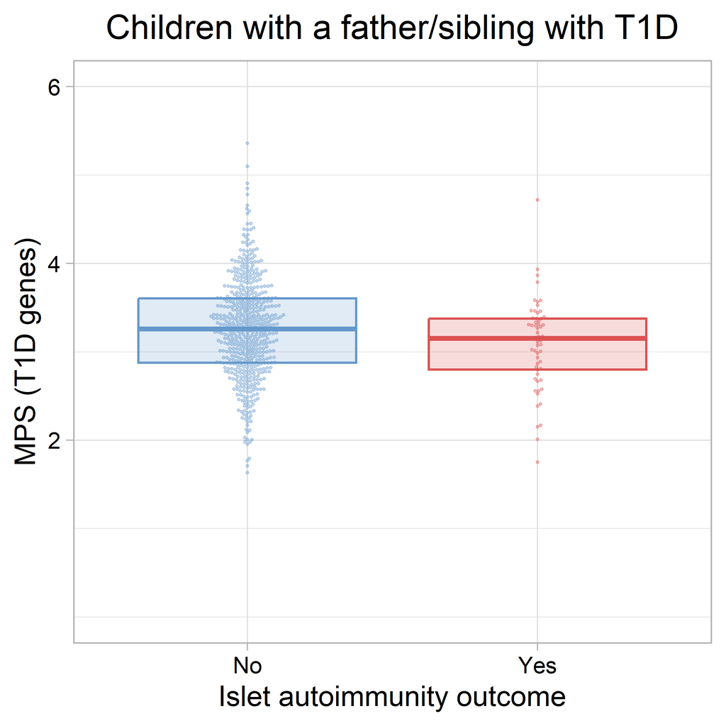

```r
# Extended Data Figure 4c

color<-c("#6699CC", "#DB5252")
alpha_color <- 1
alpha_fill <- 0.2

ExtDataFig4c <- ggplot(ExtDataFig4c_data,
                aes(x = IA_outcome,
                    y = MPS)) +
  geom_boxplot(aes(color = IA_outcome,
                   fill = IA_outcome),
               outlier.shape = NA,
               coef = 0,
               show.legend = FALSE,
               linewidth = 1) +
  geom_beeswarm(aes(color = IA_outcome),
                alpha = 0.4,
                cex = 0.6,
                show.legend = FALSE,
                size = 1) +
  scale_color_manual(breaks = c("No", "Yes"),
                     values = ggplot2::alpha(color,
                                             alpha_color)) +
  scale_fill_manual(breaks = c("No", "Yes"),
                    values = ggplot2::alpha(color,
                                            alpha_fill)) +
  scale_y_continuous(limits=c(0, 6), breaks = c(2, 4, 6)) +
  theme_light(base_size = 24) +
  theme(axis.text = element_text(colour = "black"),
        plot.title = element_text(hjust = 0.5)) +
  ylab("MPS (T1D genes)") +
  xlab("Islet autoimmunity outcome") +
  ggtitle("Children with a father/sibling with T1D")

print(ExtDataFig4c)
```

## 0.56 Extended Data Figure 4d

The MPS based on 28 CpGs linked to T1D susceptibility genes in children without a first-degree relative with T1D by islet autoimmunity outcome (ntotal = 359, n children who developed islet autoimmunity = 23).

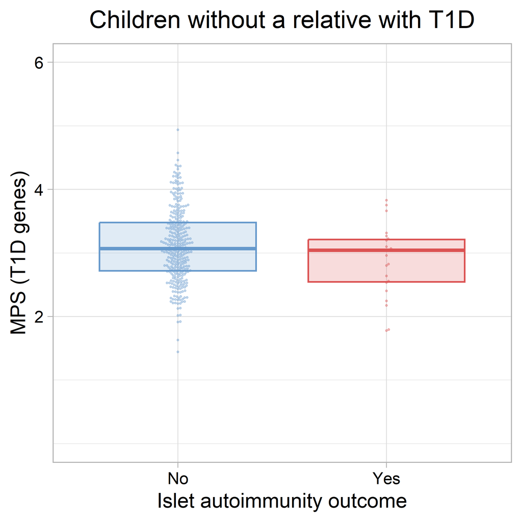

```r
# Extended Data Figure 4d

color<-c("#6699CC", "#DB5252")
alpha_color <- 1
alpha_fill <- 0.2

ExtDataFig4d <- ggplot(ExtDataFig4d_data,
                aes(x = IA_outcome,
                    y = MPS)) +
  geom_boxplot(aes(color = IA_outcome,
                   fill = IA_outcome),
               outlier.shape = NA,
               coef = 0,
               show.legend = FALSE,
               linewidth = 1) +
  geom_beeswarm(aes(color = IA_outcome),
                alpha = 0.4,
                cex = 0.6,
                show.legend = FALSE,
                size = 1) +
  scale_color_manual(breaks = c("No", "Yes"),
                     values = ggplot2::alpha(color,
                                             alpha_color)) +
  scale_fill_manual(breaks = c("No", "Yes"),
                    values = ggplot2::alpha(color,
                                            alpha_fill)) +
  scale_y_continuous(limits=c(0, 6), breaks = c(2, 4, 6)) +
  theme_light(base_size = 24) +
  theme(axis.text = element_text(colour="black"),
        plot.title = element_text(hjust = 0.5)) +
  ylab("MPS (T1D genes)") +
  xlab("Islet autoimmunity outcome") +
  ggtitle("Children without a relative with T1D")

print(ExtDataFig4d)
```

## 0.57 Extended Data Figure 4e

Validation of the MPS based on 28 CpGs linked to T1D susceptibility in children without a mother with T1D from an independent cohort (Fr1da) by islet autoimmunity outcome (ntotal = 303, n children who developed islet autoimmunity = 161).

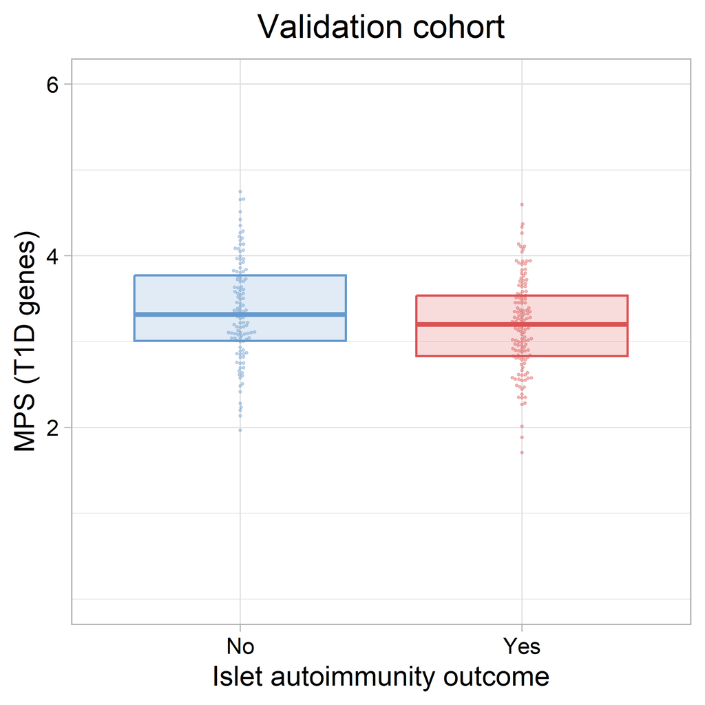

```r
# Extended Data Figure 4e

color<-c("#6699CC", "#DB5252")
alpha_color <- 1
alpha_fill <- 0.2

ExtDataFig4e <- ggplot(ExtDataFig4e_data,
                aes(x = IA_outcome,
                    y = MPS)) +
  geom_boxplot(aes(color = IA_outcome,
                   fill = IA_outcome),
               outlier.shape = NA,
               coef = 0,
               show.legend = FALSE,
               linewidth = 1) +
  geom_beeswarm(aes(color = IA_outcome),
                alpha = 0.4,
                cex = 0.6,
                show.legend = FALSE,
                size = 1) +
  scale_color_manual(breaks = c("No", "Yes"),
                     values = ggplot2::alpha(color,
                                             alpha_color)) +
  scale_fill_manual(breaks = c("No", "Yes"),
                    values = ggplot2::alpha(color,
                                            alpha_fill)) +
  scale_y_continuous(limits=c(0, 6), breaks = c(2, 4, 6)) +
  theme_light(base_size = 24) +
  theme(axis.text = element_text(colour = "black"),
        plot.title = element_text(hjust = 0.5)) +
  ylab("MPS (T1D genes)") +
  xlab("Islet autoimmunity outcome") +
  ggtitle("Validation cohort")

print(ExtDataFig4e)
```